# Actividad 4

Duvan Florez Ardila

4 de septiembre de 2019

## Minería de datos

La minería de datos es una herramienta intenta descubrir patrones en conjuntos de datos por medio de la estadística. Una implementación de esta herramienta puede ser en predicción de sucesos con respecto a un conjunto de datos.

## Cuadro comparativo

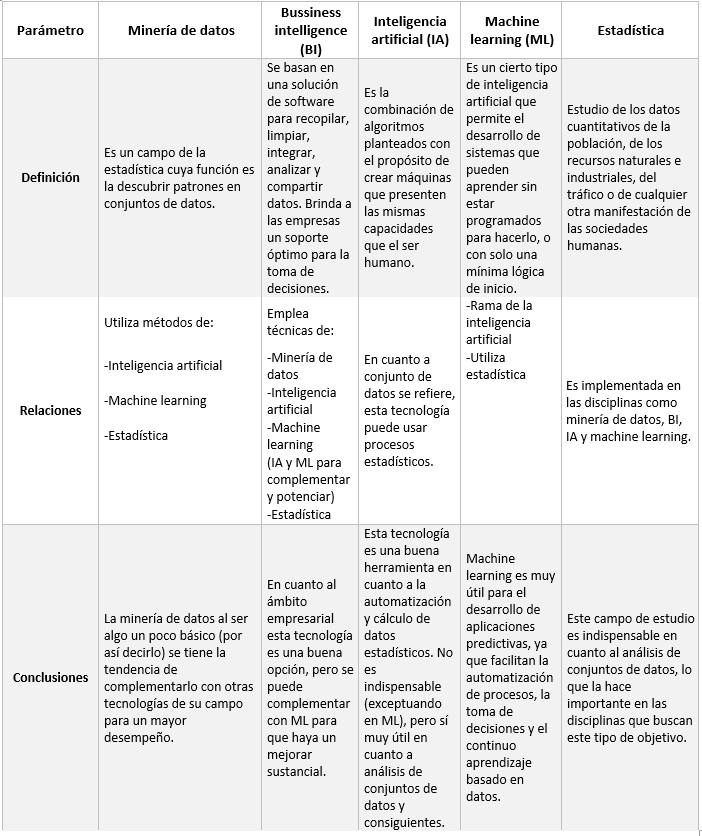

```r
knitr::include_graphics("cuadro-disci.png")
```

## Proceso de preparación de datos

Consiste en varias etapas en las cuales los datos son guiados por un plan preliminar de analisis las etapas son:

- verificar la calidad de los cuestionarios (que estos sean aceptables)
- Edición
- Codificación
- Transcribción
- Validacio y depuración
- Correción de inconsistensias (que hacer con los datos atípicos)
- Elegir una estrategia de análisis de datos

## ¿Qué es un dato faltante?

Son aquellos datos que pueden alterar de forma negativa el resultado de un análisis estadístico debido a su ausencia en estos. un ejemplo es querer sacar una media de 3 valores, pero solo tienes 2 de estos, entonces, el tercero vendría a ser el dato faltante

## ¿Qué es un dato atípico?

Son aquellos datos que se encuentran extremadamente alejados del conjunto de datos que sea mayor (normalmente son aquellos que rodean la media). ejemplo: De los 5 niños encuestados 3 dijeron tener 9 años, 1 dijo tener 8 años y el último dijo tener 64 años. El niño que dijo tener 64 años vendría a ser el dato atípico.

## ¿Qué es análisis de correlación?

Hace referencia al vínculo que tienen varios eventos, y con esta misma se averigua si existe tal vínculo. Como tal este análisis marca que tan similares son los patrones que hay en distintas muestras de varios conjuntos de datos que tengan cierta relación.

Este tipo de análisis tiene un coeficiente, el cual varía dependiendo de la correlación que exista, de modo que tal coeficiente determina si es positiva o negativa la correlación.

##### Correlación positiva

Si este coeficiente es positivo indica que los datos tienden a variar de forma proporcional.

##### Correlación negativa

Si este coeficiente es negativo indica que los datos tienden a variar de forma inversamente proporcional.

```r
# ejemplo:
a = c(3,5,9,10,20,21,24,24,27,35)
b = c(100,90,80,45,50,50,60,40,25,20)
cor(a,b)
```

```
## [1] -0.8822329
```

```r
# debido a que es menor que cero es una correlación negativa, espeficicamente negativa fuerte.
```

### Métodos de correlación

##### Coeficiente de correlación de Pearson

Es una medida lineal entre dos variables, y en esta medida se implementa la ecuación de la recta, donde cada variable de tal ecuación corresponde a una formula específica en que se relacionan dos variables aleatorias.

##### Coeficiente de correlación de Spearman

Es útil cuando las variables tienden a moverse a una misma dirección, y que ese movimiento no sea constante. En sí se implementa cuando la relación entre las variables no es lineal, aunque el coeficiente Spearman es menos sensible en cuanto a datos atípicos.

## Matriz de correlación de la base de datos obesidad

```r
bsobesidad=data.frame(read.csv(file = "base de datos obesidad.csv", dec = ",", header = TRUE, sep = ";"))
bsobesidad[1:4,c(2,3,4,19)]
```

```
##   Edad Estatura Peso   IMC
## 1   21     1.62   64 24.39
## 2   21     1.52   56 24.24
## 3   23     1.80   77 23.77
## 4   18     1.80   87 26.85
```

```r
matriz = cbind(bsobesidad$Edad,bsobesidad$Estatura, bsobesidad$Peso, bsobesidad$IMC)
# Matriz de correlación
matriz.cor = cor(matriz, method = "pearson")
dimnames(matriz.cor) = list(c("Edad", "Estatura", "Peso", "IMC"), c("Edad", "Estatura", "Peso", "IMC"))
print(matriz.cor)
```

```
##                 Edad    Estatura        Peso        IMC
## Edad      1.00000000 -0.03541246 -0.02005265 0.01209472
## Estatura -0.03541246  1.00000000  0.60478653 0.14480308
## Peso     -0.02005265  0.60478653  1.00000000 0.86956976
## IMC       0.01209472  0.14480308  0.86956976 1.00000000
```

## Lab: Introducción a R

```r
#Creación de un vector
x = c(1,2,3,4)
y = c(5,6,7,8)

#Dimensión del vector
length(x)
```

```
## [1] 4
```

```r
length(y)
```

```
## [1] 4
```

```r
#Suma entre vectores
x+y
```

```
## [1]  6  8 10 12
```

```r
#Impresión de los nombres de los datos que se hayan creados e importados. (Environment)
ls()
```

```
## [1] "a"          "b"          "bsobesidad" "matriz"     "matriz.cor"
## [6] "x"          "y"
```

```r
#Eliminación de los datos almacenados
rm(x,y) #Se eliminan los vectores X & Y
ls()
```

```
## [1] "a"          "b"          "bsobesidad" "matriz"     "matriz.cor"
```

```r
rm(list = ls()) #Se eliminan todos los datos que se encuentren
ls()
```

```
## character(0)
```

#### Matrices

```r
#Se agrega un vector y se segmenta dependiendo del número de filas y columnas
m = matrix(data = c(1,2,3,4,5,6,7,8,9), nrow = 3, ncol = 3)
print(m)
```

```
##      [,1] [,2] [,3]
## [1,]    1    4    7
## [2,]    2    5    8
## [3,]    3    6    9
```

```r
#También se puede omitir los parámetros ncol y nrow
n = matrix(data = c(6,5,4,3,2,1),3,2) # 3 filas y 2 columnas
print(n)
```

```
##      [,1] [,2]
## [1,]    6    3
## [2,]    5    2
## [3,]    4    1
```

#### Comandos matemáticos

```r
sqrt(n) #Sacar raíz cuadrada, en este caso a la matriz x
```

```
##          [,1]     [,2]
## [1,] 2.449490 1.732051
## [2,] 2.236068 1.414214
## [3,] 2.000000 1.000000
```

```r
n^2 #La función "^" lo que hace es potenciar, en este caso la matriz fue potenciada a la 2
```

```
##      [,1] [,2]
## [1,]   36    9
## [2,]   25    4
## [3,]   16    1
```

#### comandos estadísticos

```r
#(rnorm-"r = random" y "norm = normal")Crea una cantida de valores n aleatorios dependiendo de una media y desviación estándar en una población.
rx = rnorm(4)# mean = 0, sd = 1
ry = rx + rnorm(4,mean = 12, sd = 4)
cbind(rx,ry)
```

```
##              rx       ry
## [1,] -0.4484966 15.31476
## [2,] -0.9111681 11.47259
## [3,] -1.4215135 14.40991
## [4,] -0.2617685 13.35722
```

```r
cor(rx,ry) #cor() encuentra la correlación que hay entre varios conjuntos de datos, en este caso en rx y ry
```

```
## [1] 0.07759262
```

```r
#La función set.seed sirve para generar una serie de números aleatorios cuyo valores no cambien si se vuelven a crear
#Puede llegar a ser útil en cuanto a simulación se refiere
set.seed(5)
rnorm(6)
```

```
## [1] -0.84085548  1.38435934 -1.25549186  0.07014277  1.71144087 -0.60290798
```

```r
set.seed(5)
rnorm(6)
```

```
## [1] -0.84085548  1.38435934 -1.25549186  0.07014277  1.71144087 -0.60290798
```

```r
#Los valores son los mismos
set.seed(7)
dato = rnorm(6)

#mean-media
mean(dato)
```

```
## [1] -0.3223439
```

```r
#var variación
var(dato)
```

```
## [1] 1.70638
```

```r
#sd desviación estándar
sd(dato)
```

```
## [1] 1.306285
```

```r
# sd(dato) = sqrt(var(dato))
sqrt(var(dato))
```

```
## [1] 1.306285
```

#### Gráfica

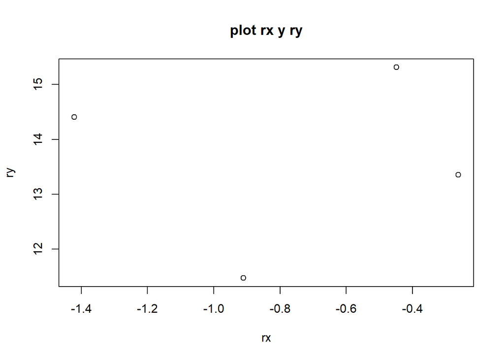

```r
plot(rx,ry, main = "plot rx y ry") #Crean un gráfico en donde se compara rx y ry
```

```r
#Esta serie de comandos sirve para guardar una gráfica, en este caso un pdf
pdf("Figure.pdf")
plot(rx,ry, main = "plot rx y ry")
dev.off()
```